# Simplified RDD

You work in a school district that is considering adding a special honors program for students that score well on a pretest at the beginning of high school. Students who score 80 or higher on the exam are automatically enrolled in honors classes that provide students with extra enrichment activities and outside-of-class support and tutoring. Administrators hope that the honors program will increase students’ final GPA.

You have access to observational (i.e. not experimental) administrative data on students at the school, with columns for their pretest score, whether they were enrolled in the honors program, and their final high school GPA.

Your colleague attempted to measure the causal effect of this honors program on final GPA. They conducted some statistical analysis in R, but they forgot to interpret anything in the document, and now they’ve moved to a different district!

Given the information provided below, interpret the results from this analysis, as well as any assumption checks or tests your colleague included. Did this honors program have have an effect on GPAs? How much? Is it significant?

```r
library(tidyverse)
library(wakefield)
library(broom)
library(rdrobust)
library(rddensity)
library(scales)

program <- read_csv("honors_program_data.csv") %>%
  mutate(pre_test_centered = pre_test - 80)
```

```r
head(program)
```

| ID | pre_test | gpa | honors | pre_test_centered |
| --- | --- | --- | --- | --- |
| 0001 | 92.4 | 3.78 | TRUE | 12.41 |
| 0002 | 72.8 | 2.85 | FALSE | -7.23 |
| 0003 | 53.7 | 2.69 | FALSE | -26.35 |
| 0004 | 98.3 | 3.38 | TRUE | 18.33 |
| 0005 | 69.7 | 2.35 | FALSE | -10.29 |
| 0006 | 68.1 | 2.57 | FALSE | -11.93 |

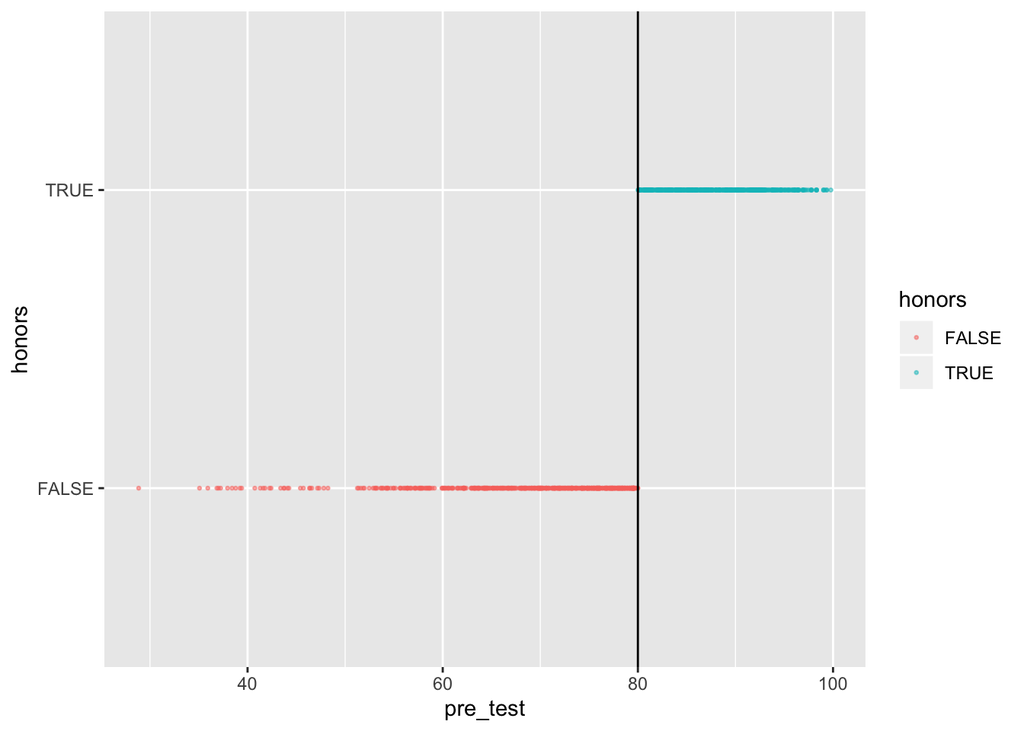

```r
ggplot(program, aes(x = pre_test, y = honors, color = honors)) +
  geom_point(size = 0.5, alpha = 0.5) +
  geom_vline(xintercept = 80)
```

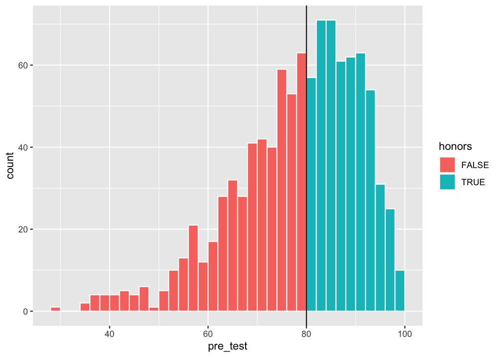

```r
ggplot(program, aes(x = pre_test, fill = honors)) +
  geom_histogram(binwidth = 2, color = "white", boundary = 80) +
  geom_vline(xintercept = 80)
```

```r
density_check <- rddensity(program$pre_test, c = 80)
summary(density_check)
```

```
##
## RD Manipulation Test using local polynomial density estimation.
##
## Number of obs =       1000
## Model =               unrestricted
## Kernel =              triangular
## BW method =           comb
## VCE method =          jackknife
##
## Cutoff c = 80         Left of c           Right of c
## Number of obs         495                 505
## Eff. Number of obs    334                 418
## Order est. (p)        2                   2
## Order bias (q)        3                   3
## BW est. (h)           14.642              12.792
##
## Method                T                   P > |T|
## Robust                -0.5146             0.6068
```

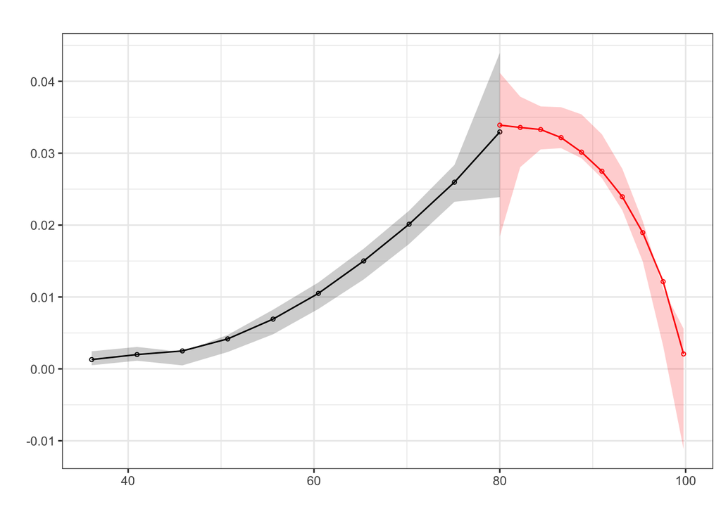

```r
plot_mccrary <- rdplotdensity(rdd = density_check,
                              X = program$pre_test,
                              type = "both")
```

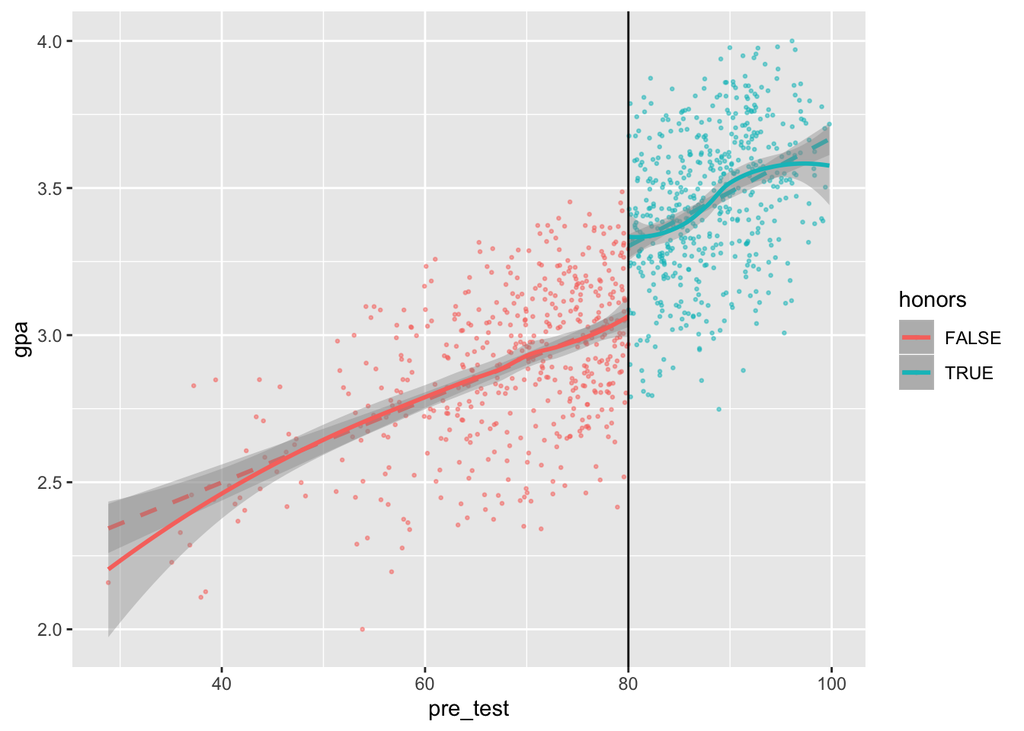

```r
ggplot(program, aes(x = pre_test, y = gpa, color = honors)) +
  geom_point(size = 0.5, alpha = 0.5) +
  geom_smooth(method = "lm", linetype = "dashed") +
  geom_smooth(method = "loess") +
  geom_vline(xintercept = 80)
```

```r
# Parametric stuff
model_parametric_5 <- lm(gpa ~ pre_test_centered + honors,
                         data = filter(program,
                                       pre_test_centered >= -5,
                                       pre_test_centered <= 5))
tidy(model_parametric_5)
```

| term | estimate | std.error | statistic | p.value |
| --- | --- | --- | --- | --- |
| (Intercept) | 3.055 | 0.030 | 102.84 | 0.000 |
| pre_test_centered | 0.019 | 0.009 | 2.04 | 0.043 |
| honorsTRUE | 0.239 | 0.053 | 4.49 | 0.000 |

```r
model_parametric_10 <- lm(gpa ~ pre_test_centered + honors,
                          data = filter(program,
                                        pre_test_centered >= -10,
                                        pre_test_centered <= 10))
tidy(model_parametric_10)
```

| term | estimate | std.error | statistic | p.value |
| --- | --- | --- | --- | --- |
| (Intercept) | 3.068 | 0.022 | 142.02 | 0 |
| pre_test_centered | 0.017 | 0.003 | 4.87 | 0 |
| honorsTRUE | 0.238 | 0.039 | 6.16 | 0 |

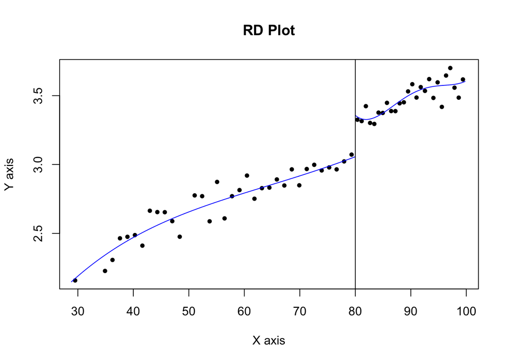

```r
# Nonparametric stuff
rdplot(y = program$gpa, x = program$pre_test, c = 80)
```

```r
rdrobust(y = program$gpa, x = program$pre_test, c = 80) %>%
  summary()
```

```
## Call: rdrobust
##
## Number of Obs.                 1000
## BW type                       mserd
## Kernel                   Triangular
## VCE method                       NN
##
## Number of Obs.                 495         505
## Eff. Number of Obs.            207         252
## Order est. (p)                   1           1
## Order bias  (p)                  2           2
## BW est. (h)                  7.604       7.604
## BW bias (b)                 11.517      11.517
## rho (h/b)                    0.660       0.660
##
## =============================================================================
##         Method     Coef. Std. Err.         z     P>|z|      [ 95% C.I. ]
## =============================================================================
##   Conventional     0.247     0.050     4.965     0.000     [0.149 , 0.344]
##         Robust         -         -     4.119     0.000     [0.130 , 0.367]
## =============================================================================
```

```r
rdrobust(y = program$gpa, x = program$pre_test,
         c = 80, h = 7.604 * 2) %>%
  summary()
```

```
## Call: rdrobust
##
## Number of Obs.                 1000
## BW type                      Manual
## Kernel                   Triangular
## VCE method                       NN
##
## Number of Obs.                 495         505
## Eff. Number of Obs.            342         459
## Order est. (p)                   1           1
## Order bias  (p)                  2           2
## BW est. (h)                 15.208      15.208
## BW bias (b)                 15.208      15.208
## rho (h/b)                    1.000       1.000
##
## =============================================================================
##         Method     Coef. Std. Err.         z     P>|z|      [ 95% C.I. ]
## =============================================================================
##   Conventional     0.240     0.035     6.924     0.000     [0.172 , 0.308]
##         Robust         -         -     4.819     0.000     [0.150 , 0.356]
## =============================================================================
```

```r
rdrobust(y = program$gpa, x = program$pre_test,
         c = 80, h = 7.604 / 2) %>%
  summary()
```

```
## Call: rdrobust
##
## Number of Obs.                 1000
## BW type                      Manual
## Kernel                   Triangular
## VCE method                       NN
##
## Number of Obs.                 495         505
## Eff. Number of Obs.            108         119
## Order est. (p)                   1           1
## Order bias  (p)                  2           2
## BW est. (h)                  3.802       3.802
## BW bias (b)                  3.802       3.802
## rho (h/b)                    1.000       1.000
##
## =============================================================================
##         Method     Coef. Std. Err.         z     P>|z|      [ 95% C.I. ]
## =============================================================================
##   Conventional     0.232     0.072     3.212     0.001     [0.090 , 0.374]
##         Robust         -         -     1.434     0.152    [-0.060 , 0.389]
## =============================================================================
```

```r
rdrobust(y = program$gpa, x = program$pre_test,
         c = 80, kernel = "epanechnikov") %>%
  summary()
```

```
## Call: rdrobust
##
## Number of Obs.                 1000
## BW type                       mserd
## Kernel                   Epanechnikov
## VCE method                       NN
##
## Number of Obs.                 495         505
## Eff. Number of Obs.            181         207
## Order est. (p)                   1           1
## Order bias  (p)                  2           2
## BW est. (h)                  6.380       6.380
## BW bias (b)                 10.187      10.187
## rho (h/b)                    0.626       0.626
##
## =============================================================================
##         Method     Coef. Std. Err.         z     P>|z|      [ 95% C.I. ]
## =============================================================================
##   Conventional     0.241     0.052     4.625     0.000     [0.139 , 0.343]
##         Robust         -         -     3.719     0.000     [0.111 , 0.357]
## =============================================================================
```